# Loan Data From Prosper

## by Bala Peri

## Preliminary Wrangling

> This data set contains 113,937 loans with 81 variables on each loan, including loan amount, borrower rate (or interest rate), current loan status, borrower income, and many others.

```python
# import all packages and set plots to be embedded inline
import numpy as np
import pandas as pd
import matplotlib.pyplot as plt
import seaborn as sb

%matplotlib inline
```

```python
#displaying max number of rows and columns
pd.set_option('display.max_column',None)
pd.set_option('display.max_rows',None)
```

```python
#load the dataset
df_prosper_data=pd.read_csv("prosperLoanData.csv")
df_prosper_data.head()
```

|  | ListingKey | ListingNumber | ListingCreationDate | CreditGrade | Term | LoanStatus | ClosedDate | BorrowerAPR | BorrowerRate | LenderYield | EstimatedEffectiveYield | EstimatedLoss | EstimatedReturn | ProsperRating (numeric) | ProsperRating (Alpha) | ProsperScore | ListingCategory (numeric) | BorrowerState | Occupation | EmploymentStatus | EmploymentStatusDuration | IsBorrowerHomeowner | CurrentlyInGroup | GroupKey | DateCreditPulled | CreditScoreRangeLower | CreditScoreRangeUpper | FirstRecordedCreditLine | CurrentCreditLines | … |
| --- | --- | --- | --- | --- | --- | --- | --- | --- | --- | --- | --- | --- | --- | --- | --- | --- | --- | --- | --- | --- | --- | --- | --- | --- | --- | --- | --- | --- | --- | --- |
| 0 | 1021339766868145413AB3B | 193129 | 2007-08-26 19:09:29.263000000 | C | 36 | Completed | 2009-08-14 00:00:00 | 0.16516 | 0.1580 | 0.1380 | NaN | NaN | NaN | NaN | NaN | NaN | 0 | CO | Other | Self-employed | 2.0 | True | True | NaN | 2007-08-26 18:41:46.780000000 | 640.0 | 659.0 | 2001-10-11 00:00:00 | 5.0 | … |
| 1 | 10273602499503308B223C1 | 1209647 | 2014-02-27 08:28:07.900000000 | NaN | 36 | Current | NaN | 0.12016 | 0.0920 | 0.0820 | 0.07960 | 0.0249 | 0.05470 | 6.0 | A | 7.0 | 2 | CO | Professional | Employed | 44.0 | False | False | NaN | 2014-02-27 08:28:14 | 680.0 | 699.0 | 1996-03-18 00:00:00 | 14.0 | … |
| 2 | 0EE9337825851032864889A | 81716 | 2007-01-05 15:00:47.090000000 | HR | 36 | Completed | 2009-12-17 00:00:00 | 0.28269 | 0.2750 | 0.2400 | NaN | NaN | NaN | NaN | NaN | NaN | 0 | GA | Other | Not available | NaN | False | True | 783C3371218786870A73D20 | 2007-01-02 14:09:10.060000000 | 480.0 | 499.0 | 2002-07-27 00:00:00 | NaN | … |
| 3 | 0EF5356002482715299901A | 658116 | 2012-10-22 11:02:35.010000000 | NaN | 36 | Current | NaN | 0.12528 | 0.0974 | 0.0874 | 0.08490 | 0.0249 | 0.06000 | 6.0 | A | 9.0 | 16 | GA | Skilled Labor | Employed | 113.0 | True | False | NaN | 2012-10-22 11:02:32 | 800.0 | 819.0 | 1983-02-28 00:00:00 | 5.0 | … |
| 4 | 0F023589499656230C5E3E2 | 909464 | 2013-09-14 18:38:39.097000000 | NaN | 36 | Current | NaN | 0.24614 | 0.2085 | 0.1985 | 0.18316 | 0.0925 | 0.09066 | 3.0 | D | 4.0 | 2 | MN | Executive | Employed | 44.0 | True | False | NaN | 2013-09-14 18:38:44 | 680.0 | 699.0 | 2004-02-20 00:00:00 | 19.0 | … |

```python
#get the rows,info
print(df_prosper_data.shape)
print(df_prosper_data.info())
df_prosper_data.head()
```

```
(113937, 81)
<class 'pandas.core.frame.DataFrame'>
RangeIndex: 113937 entries, 0 to 113936
Data columns (total 81 columns):
 #   Column                               Non-Null Count   Dtype
---  ------                               --------------   -----
 0   ListingKey                           113937 non-null  object
 1   ListingNumber                        113937 non-null  int64
 2   ListingCreationDate                  113937 non-null  object
 3   CreditGrade                          28953 non-null   object
 4   Term                                 113937 non-null  int64
 5   LoanStatus                           113937 non-null  object
 6   ClosedDate                           55089 non-null   object
 7   BorrowerAPR                          113912 non-null  float64
 8   BorrowerRate                         113937 non-null  float64
```

[output cut: 75 more lines]

|  | ListingKey | ListingNumber | ListingCreationDate | CreditGrade | Term | LoanStatus | ClosedDate | BorrowerAPR | BorrowerRate | LenderYield | EstimatedEffectiveYield | EstimatedLoss | EstimatedReturn | ProsperRating (numeric) | ProsperRating (Alpha) | ProsperScore | ListingCategory (numeric) | BorrowerState | Occupation | EmploymentStatus | EmploymentStatusDuration | IsBorrowerHomeowner | CurrentlyInGroup | GroupKey | DateCreditPulled | CreditScoreRangeLower | CreditScoreRangeUpper | FirstRecordedCreditLine | CurrentCreditLines | … |
| --- | --- | --- | --- | --- | --- | --- | --- | --- | --- | --- | --- | --- | --- | --- | --- | --- | --- | --- | --- | --- | --- | --- | --- | --- | --- | --- | --- | --- | --- | --- |
| 0 | 1021339766868145413AB3B | 193129 | 2007-08-26 19:09:29.263000000 | C | 36 | Completed | 2009-08-14 00:00:00 | 0.16516 | 0.1580 | 0.1380 | NaN | NaN | NaN | NaN | NaN | NaN | 0 | CO | Other | Self-employed | 2.0 | True | True | NaN | 2007-08-26 18:41:46.780000000 | 640.0 | 659.0 | 2001-10-11 00:00:00 | 5.0 | … |
| 1 | 10273602499503308B223C1 | 1209647 | 2014-02-27 08:28:07.900000000 | NaN | 36 | Current | NaN | 0.12016 | 0.0920 | 0.0820 | 0.07960 | 0.0249 | 0.05470 | 6.0 | A | 7.0 | 2 | CO | Professional | Employed | 44.0 | False | False | NaN | 2014-02-27 08:28:14 | 680.0 | 699.0 | 1996-03-18 00:00:00 | 14.0 | … |
| 2 | 0EE9337825851032864889A | 81716 | 2007-01-05 15:00:47.090000000 | HR | 36 | Completed | 2009-12-17 00:00:00 | 0.28269 | 0.2750 | 0.2400 | NaN | NaN | NaN | NaN | NaN | NaN | 0 | GA | Other | Not available | NaN | False | True | 783C3371218786870A73D20 | 2007-01-02 14:09:10.060000000 | 480.0 | 499.0 | 2002-07-27 00:00:00 | NaN | … |
| 3 | 0EF5356002482715299901A | 658116 | 2012-10-22 11:02:35.010000000 | NaN | 36 | Current | NaN | 0.12528 | 0.0974 | 0.0874 | 0.08490 | 0.0249 | 0.06000 | 6.0 | A | 9.0 | 16 | GA | Skilled Labor | Employed | 113.0 | True | False | NaN | 2012-10-22 11:02:32 | 800.0 | 819.0 | 1983-02-28 00:00:00 | 5.0 | … |
| 4 | 0F023589499656230C5E3E2 | 909464 | 2013-09-14 18:38:39.097000000 | NaN | 36 | Current | NaN | 0.24614 | 0.2085 | 0.1985 | 0.18316 | 0.0925 | 0.09066 | 3.0 | D | 4.0 | 2 | MN | Executive | Employed | 44.0 | True | False | NaN | 2013-09-14 18:38:44 | 680.0 | 699.0 | 2004-02-20 00:00:00 | 19.0 | … |

```python
#finding duplicates in the dataset
sum(df_prosper_data.duplicated())
```

```
0
```

```python
#filter out loans with prosperscores
df_prosper_data1=df_prosper_data[df_prosper_data['ProsperScore'].isnull()==False]
df_prosper_data1.head()
```

|  | ListingKey | ListingNumber | ListingCreationDate | CreditGrade | Term | LoanStatus | ClosedDate | BorrowerAPR | BorrowerRate | LenderYield | EstimatedEffectiveYield | EstimatedLoss | EstimatedReturn | ProsperRating (numeric) | ProsperRating (Alpha) | ProsperScore | ListingCategory (numeric) | BorrowerState | Occupation | EmploymentStatus | EmploymentStatusDuration | IsBorrowerHomeowner | CurrentlyInGroup | GroupKey | DateCreditPulled | CreditScoreRangeLower | CreditScoreRangeUpper | FirstRecordedCreditLine | CurrentCreditLines | … |
| --- | --- | --- | --- | --- | --- | --- | --- | --- | --- | --- | --- | --- | --- | --- | --- | --- | --- | --- | --- | --- | --- | --- | --- | --- | --- | --- | --- | --- | --- | --- |
| 1 | 10273602499503308B223C1 | 1209647 | 2014-02-27 08:28:07.900000000 | NaN | 36 | Current | NaN | 0.12016 | 0.0920 | 0.0820 | 0.07960 | 0.0249 | 0.05470 | 6.0 | A | 7.0 | 2 | CO | Professional | Employed | 44.0 | False | False | NaN | 2014-02-27 08:28:14 | 680.0 | 699.0 | 1996-03-18 00:00:00 | 14.0 | … |
| 3 | 0EF5356002482715299901A | 658116 | 2012-10-22 11:02:35.010000000 | NaN | 36 | Current | NaN | 0.12528 | 0.0974 | 0.0874 | 0.08490 | 0.0249 | 0.06000 | 6.0 | A | 9.0 | 16 | GA | Skilled Labor | Employed | 113.0 | True | False | NaN | 2012-10-22 11:02:32 | 800.0 | 819.0 | 1983-02-28 00:00:00 | 5.0 | … |
| 4 | 0F023589499656230C5E3E2 | 909464 | 2013-09-14 18:38:39.097000000 | NaN | 36 | Current | NaN | 0.24614 | 0.2085 | 0.1985 | 0.18316 | 0.0925 | 0.09066 | 3.0 | D | 4.0 | 2 | MN | Executive | Employed | 44.0 | True | False | NaN | 2013-09-14 18:38:44 | 680.0 | 699.0 | 2004-02-20 00:00:00 | 19.0 | … |
| 5 | 0F05359734824199381F61D | 1074836 | 2013-12-14 08:26:37.093000000 | NaN | 60 | Current | NaN | 0.15425 | 0.1314 | 0.1214 | 0.11567 | 0.0449 | 0.07077 | 5.0 | B | 10.0 | 1 | NM | Professional | Employed | 82.0 | True | False | NaN | 2013-12-14 08:26:40 | 740.0 | 759.0 | 1973-03-01 00:00:00 | 21.0 | … |
| 6 | 0F0A3576754255009D63151 | 750899 | 2013-04-12 09:52:56.147000000 | NaN | 36 | Current | NaN | 0.31032 | 0.2712 | 0.2612 | 0.23820 | 0.1275 | 0.11070 | 2.0 | E | 2.0 | 1 | KS | Sales - Retail | Employed | 172.0 | False | False | NaN | 2013-04-12 09:52:53 | 680.0 | 699.0 | 2000-09-29 00:00:00 | 10.0 | … |

```python
#drop columns with most null values and other unwanted columns
df_prosper_data1.drop(['ListingKey','ListingNumber','ListingCreationDate','CreditGrade','ClosedDate','LenderYield','EstimatedEffectiveYield',
     'EstimatedLoss','EstimatedReturn','CurrentlyInGroup','GroupKey','DateCreditPulled','FirstRecordedCreditLine','LoanKey',
     'TotalProsperLoans','TotalProsperPaymentsBilled','OnTimeProsperPayments','ProsperPaymentsLessThanOneMonthLate',
     'ProsperPaymentsOneMonthPlusLate','ProsperPrincipalBorrowed','ProsperPrincipalOutstanding','ScorexChangeAtTimeOfListing',
     'LoanFirstDefaultedCycleNumber'],axis=1,inplace=True)
```

```python
#check for the number of rows and columns in the new dataframe containing not null prosper score
print(df_prosper_data1.shape)
df_prosper_data1.info()
df_prosper_data1.head()
```

```
(84853, 58)
<class 'pandas.core.frame.DataFrame'>
Int64Index: 84853 entries, 1 to 113936
Data columns (total 58 columns):
 #   Column                              Non-Null Count  Dtype
---  ------                              --------------  -----
 0   Term                                84853 non-null  int64
 1   LoanStatus                          84853 non-null  object
 2   BorrowerAPR                         84853 non-null  float64
 3   BorrowerRate                        84853 non-null  float64
 4   ProsperRating (numeric)             84853 non-null  float64
 5   ProsperRating (Alpha)               84853 non-null  object
 6   ProsperScore                        84853 non-null  float64
 7   ListingCategory (numeric)           84853 non-null  int64
 8   BorrowerState                       84853 non-null  object
```

[output cut: 51 more lines]

|  | Term | LoanStatus | BorrowerAPR | BorrowerRate | ProsperRating (numeric) | ProsperRating (Alpha) | ProsperScore | ListingCategory (numeric) | BorrowerState | Occupation | EmploymentStatus | EmploymentStatusDuration | IsBorrowerHomeowner | CreditScoreRangeLower | CreditScoreRangeUpper | CurrentCreditLines | OpenCreditLines | TotalCreditLinespast7years | OpenRevolvingAccounts | OpenRevolvingMonthlyPayment | InquiriesLast6Months | TotalInquiries | CurrentDelinquencies | AmountDelinquent | DelinquenciesLast7Years | PublicRecordsLast10Years | PublicRecordsLast12Months | RevolvingCreditBalance | BankcardUtilization | … |
| --- | --- | --- | --- | --- | --- | --- | --- | --- | --- | --- | --- | --- | --- | --- | --- | --- | --- | --- | --- | --- | --- | --- | --- | --- | --- | --- | --- | --- | --- | --- |
| 1 | 36 | Current | 0.12016 | 0.0920 | 6.0 | A | 7.0 | 2 | CO | Professional | Employed | 44.0 | False | 680.0 | 699.0 | 14.0 | 14.0 | 29.0 | 13 | 389.0 | 3.0 | 5.0 | 0.0 | 0.0 | 0.0 | 1.0 | 0.0 | 3989.0 | 0.21 | … |
| 3 | 36 | Current | 0.12528 | 0.0974 | 6.0 | A | 9.0 | 16 | GA | Skilled Labor | Employed | 113.0 | True | 800.0 | 819.0 | 5.0 | 5.0 | 29.0 | 7 | 115.0 | 0.0 | 1.0 | 4.0 | 10056.0 | 14.0 | 0.0 | 0.0 | 1444.0 | 0.04 | … |
| 4 | 36 | Current | 0.24614 | 0.2085 | 3.0 | D | 4.0 | 2 | MN | Executive | Employed | 44.0 | True | 680.0 | 699.0 | 19.0 | 19.0 | 49.0 | 6 | 220.0 | 1.0 | 9.0 | 0.0 | 0.0 | 0.0 | 0.0 | 0.0 | 6193.0 | 0.81 | … |
| 5 | 60 | Current | 0.15425 | 0.1314 | 5.0 | B | 10.0 | 1 | NM | Professional | Employed | 82.0 | True | 740.0 | 759.0 | 21.0 | 17.0 | 49.0 | 13 | 1410.0 | 0.0 | 2.0 | 0.0 | 0.0 | 0.0 | 0.0 | 0.0 | 62999.0 | 0.39 | … |
| 6 | 36 | Current | 0.31032 | 0.2712 | 2.0 | E | 2.0 | 1 | KS | Sales - Retail | Employed | 172.0 | False | 680.0 | 699.0 | 10.0 | 7.0 | 20.0 | 6 | 214.0 | 0.0 | 0.0 | 0.0 | 0.0 | 0.0 | 0.0 | 0.0 | 5812.0 | 0.72 | … |

### What is the structure of your dataset?

> There are 84853 rows and 58 columns in the dataset,after dropping few columns and filtering only rows that have prosperscore not null for the analysis.

### What is/are the main feature(s) of interest in your dataset?

##### 1.what factors affect a loan's outcome status?

> debt to income ratio,credit score,occupation,prosperscore

##### 2.what factors affects the BorrowerAPR?

> BorrowerRate ,prosperscore,prosper rating,DelinquenciesLast7Years ,Availablebankcredit,creditscore,debt to income ratio

### What features in the dataset do you think will help support your investigation into your feature(s) of interest?

> BorrowerRate ,prosperscore,prosper rating,DelinquenciesLast7Years,Available bank credit,creditscore,DebtToIncomeRatio

## Univariate Exploration

> In this section, investigate distributions of individual variables. If you see unusual points or outliers, take a deeper look to clean things up and prepare yourself to look at relationships between variables.

#### 1.What factors affect a loan's outcome status?

#### . prosperscore

#### . occupation

#### . debt to income ratio

#### . DelinquenciesLast7Years

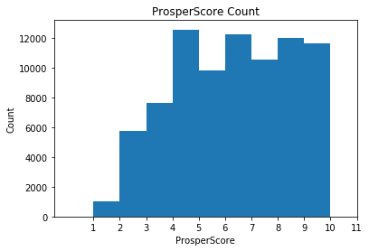

```python
#1.prosperscore being numeric,we can plot using histograms

bin_size=np.arange(0,df_prosper_data1['ProsperScore'].max(),1)
plt.hist(df_prosper_data1['ProsperScore'],bins=bin_size);
plt.xticks(np.arange(1,df_prosper_data1['ProsperScore'].max()+1,1))
plt.xlabel("ProsperScore")
plt.ylabel("Count")
plt.title("ProsperScore Count")
```

#### The above plot shows,the number of borrowers with prosper score between 4 and 9 is more compared to prosper score less than 4 and greater than 9.

#### The chances of borrowers with prosper score between 4 and 9 getting loan is high,with 1 thing to note that there were comparitively less borrowers with a prosperscore > 9.

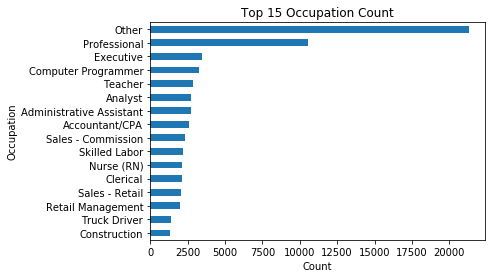

```python
#2.Occupation is a categorical variable,using barh chart and also finind the top 15 occupations.
df_prosper_data1['Occupation'].value_counts()[15::-1].plot(kind='barh')
plt.xlabel('Count')
plt.ylabel("Occupation")
plt.title("Top 15 Occupation Count")
```

#### Most of the borrowers are in the other category,maybe they dont want to reveal their occupation.Further analysis need to be done on whether 'other' category is eligible for loan.

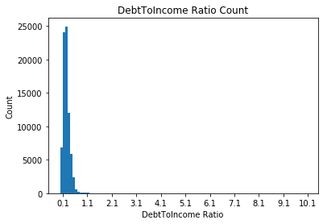

```python
# Debt To Income Ratio
bin_size=np.arange(0,df_prosper_data1['DebtToIncomeRatio'].max(),.1)
plt.hist(df_prosper_data1['DebtToIncomeRatio'],bins=bin_size);
#plt.xticks([0,.1,.2,.3,.4,.5,.6,.7,.8,.9,1])
plt.xticks(np.arange(.1,df_prosper_data1['DebtToIncomeRatio'].max()+1,1))
plt.xlabel("DebtToIncome Ratio")
plt.ylabel("Count")
plt.title("DebtToIncome Ratio Count");
```

#### Most of the borrowers debt to income ratio is less than .4,which seems to be the ideal ratio rule.So debt to income ratio can be considered for loan eligability.

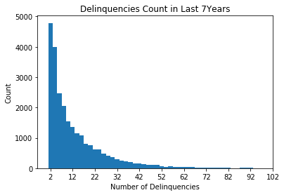

```python
#4.DelinquenciesLast7Years is a numeric variable so choosing histogram.
#excluding 0 delinqunecies counts

bin_size=np.arange(1,df_prosper_data1['DelinquenciesLast7Years'].max(),2)
plt.hist(df_prosper_data1['DelinquenciesLast7Years'],bins=bin_size);
plt.xticks(np.arange(2,df_prosper_data1['DelinquenciesLast7Years'].max()+10,10))
plt.title("Delinquencies Count in Last 7Years")
plt.ylabel("Count")
plt.xlabel("Number of Delinquencies")
```

#### From the above plot ,loan eligibilty decreases exponentially with the number of delinquencies in the last 7yrs.

#### 2. What are the features that affect BorrowersAPR ?

#### . Borrowers rate

#### . ProsperRating

#### . ProsperScore

#### . CreditScore

#### . AvailableBankcardCredit

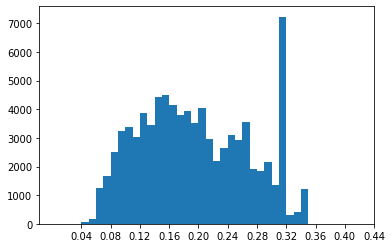

```python
#Histogram for borrowerrate

bin_size= np.arange(0,df_prosper_data1['BorrowerRate'].max(),.01)
plt.hist(df_prosper_data1['BorrowerRate'],bins=bin_size)
plt.xticks(np.arange(.04,df_prosper_data1['BorrowerRate'].max()+.1,.04));
```

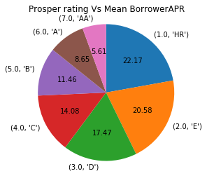

```python
#Prosper rating


sorted_counts=df_prosper_data1.groupby(['ProsperRating (numeric)','ProsperRating (Alpha)'])['BorrowerAPR'].mean()
plt.pie(sorted_counts,labels=sorted_counts.index,startangle=90,counterclock=False,autopct='%1.2f')
plt.axis('square')
plt.title("Prosper rating Vs Mean BorrowerAPR")
```

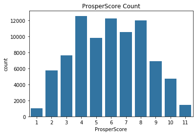

```python
#ProsperScore barplot
base_color=sb.color_palette()[0]
sb.countplot(data=df_prosper_data1,x='ProsperScore',color=base_color)
plt.title("ProsperScore Count")
```

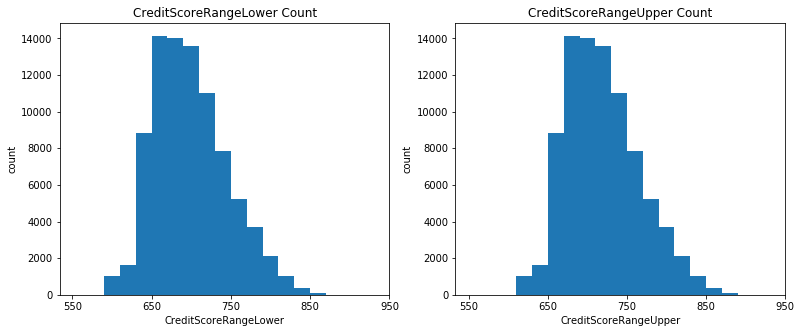

```python
#creditscore plots

plt.figure(figsize= [13,5])

plt.subplot(1, 2, 1)
bin_size=np.arange(550,df_prosper_data1['CreditScoreRangeLower'].max(),20)
plt.hist(data=df_prosper_data1, x='CreditScoreRangeLower', bins=bin_size)
plt.xticks(np.arange(550,1000,100))
plt.title('CreditScoreRangeLower Count')
plt.xlabel('CreditScoreRangeLower')
plt.ylabel('count')

plt.subplot(1, 2, 2)
bin_size=np.arange(550,df_prosper_data1['CreditScoreRangeUpper'].max(),20)
plt.hist(data=df_prosper_data1, x='CreditScoreRangeUpper', bins=bin_size)
plt.xticks(np.arange(550,1000,100))
plt.title('CreditScoreRangeUpper Count')
plt.xlabel('CreditScoreRangeUpper')
plt.ylabel('count');
```

#### There is no much difference in the plots for creditscorelowerrange and credit score upper range.

```python
#filtering data of borrowers with credit <150000
df_low_credit=df_prosper_data1.query('AvailableBankcardCredit <= 150000')
df_low_credit.head()
```

|  | Term | LoanStatus | BorrowerAPR | BorrowerRate | ProsperRating (numeric) | ProsperRating (Alpha) | ProsperScore | ListingCategory (numeric) | BorrowerState | Occupation | EmploymentStatus | EmploymentStatusDuration | IsBorrowerHomeowner | CreditScoreRangeLower | CreditScoreRangeUpper | CurrentCreditLines | OpenCreditLines | TotalCreditLinespast7years | OpenRevolvingAccounts | OpenRevolvingMonthlyPayment | InquiriesLast6Months | TotalInquiries | CurrentDelinquencies | AmountDelinquent | DelinquenciesLast7Years | PublicRecordsLast10Years | PublicRecordsLast12Months | RevolvingCreditBalance | BankcardUtilization | … |
| --- | --- | --- | --- | --- | --- | --- | --- | --- | --- | --- | --- | --- | --- | --- | --- | --- | --- | --- | --- | --- | --- | --- | --- | --- | --- | --- | --- | --- | --- | --- |
| 1 | 36 | Current | 0.12016 | 0.0920 | 6.0 | A | 7 | 2 | CO | Professional | Employed | 44.0 | False | 680.0 | 699.0 | 14.0 | 14.0 | 29.0 | 13 | 389.0 | 3.0 | 5.0 | 0.0 | 0.0 | 0 | 1.0 | 0.0 | 3989.0 | 0.21 | … |
| 3 | 36 | Current | 0.12528 | 0.0974 | 6.0 | A | 9 | 16 | GA | Skilled Labor | Employed | 113.0 | True | 800.0 | 819.0 | 5.0 | 5.0 | 29.0 | 7 | 115.0 | 0.0 | 1.0 | 4.0 | 10056.0 | 14 | 0.0 | 0.0 | 1444.0 | 0.04 | … |
| 4 | 36 | Current | 0.24614 | 0.2085 | 3.0 | D | 4 | 2 | MN | Executive | Employed | 44.0 | True | 680.0 | 699.0 | 19.0 | 19.0 | 49.0 | 6 | 220.0 | 1.0 | 9.0 | 0.0 | 0.0 | 0 | 0.0 | 0.0 | 6193.0 | 0.81 | … |
| 5 | 60 | Current | 0.15425 | 0.1314 | 5.0 | B | 10 | 1 | NM | Professional | Employed | 82.0 | True | 740.0 | 759.0 | 21.0 | 17.0 | 49.0 | 13 | 1410.0 | 0.0 | 2.0 | 0.0 | 0.0 | 0 | 0.0 | 0.0 | 62999.0 | 0.39 | … |
| 6 | 36 | Current | 0.31032 | 0.2712 | 2.0 | E | 2 | 1 | KS | Sales - Retail | Employed | 172.0 | False | 680.0 | 699.0 | 10.0 | 7.0 | 20.0 | 6 | 214.0 | 0.0 | 0.0 | 0.0 | 0.0 | 0 | 0.0 | 0.0 | 5812.0 | 0.72 | … |

```python
#filtering data of borrowers with credit >150000
df_higher_credit= df_prosper_data1.query('AvailableBankcardCredit > 150000')
len(df_higher_credit)
```

```
113
```

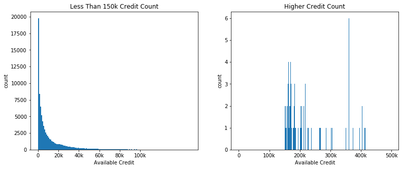

```python
#plot for availablebankcredit

plt.figure(figsize= [13,5])

plt.subplot(1,2,1)
bin_size=np.arange(0,df_low_credit['AvailableBankcardCredit'].max(),1000)
plt.hist(df_low_credit['AvailableBankcardCredit'],bins=bin_size);
plt.xticks([0,20000,40000,60000,80000,100000],[0,'20k','40k','60k','80k','100k'])
plt.xlabel("Available Credit")
plt.ylabel("count")
plt.title('Less Than 150k Credit Count')

#plot for higher >150k credit
plt.subplot(1,2,2)
bin_size=np.arange(0,df_higher_credit['AvailableBankcardCredit'].max(),1000)
plt.hist(df_higher_credit['AvailableBankcardCredit'],bins=bin_size);
plt.xticks([0,100000,200000,300000,400000,500000],[0,'100k','200k','300k','400k','500k'])
plt.xlabel("Available Credit")
plt.ylabel("count")
plt.title('Higher Credit Count')
```

#### Most of the borrowers have credit <=150k as shown in plot 1 and very few around 113 borrowers have credit >150k shown in plot 2.

### Discuss the distribution(s) of your variable(s) of interest. Were there any unusual points? Did you need to perform any transformations?

> The available bank credit feature has most of the borrowers less than 100k credit.There were around 113 borrowers with greater credit .I have made 2 different plots to show the same by filtering borrowers with credit less than or equal to 150k and borrowers greater than 150k.

### Of the features you investigated, were there any unusual distributions? Did you perform any operations on the data to tidy, adjust, or change the form of the data? If so, why did you do this?

> BorrowerAPR had higher count for certain % of APR range compared to others.Didnt do anything just considered it as outlier.

## Bivariate Exploration

> In this section, investigate relationships between pairs of variables in your data. Make sure the variables that you cover here have been introduced in some fashion in the previous section (univariate exploration).
1. BorrowerAPR vs Borrowers rate
2. BorrowerAPR vs ProsperRating
3. BorrowerAPR vs ProsperScore
4. BorrowerAPR vs CreditScore
5. BorrowerAPR vs AvailableBankcardCredit

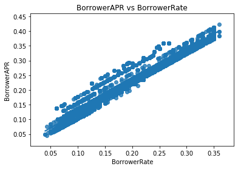

```python
#1. BorrowerAPR vs BorrowerRate
sb.regplot(data=df_prosper_data1,y='BorrowerAPR',x='BorrowerRate')
plt.title("BorrowerAPR vs BorrowerRate")
```

#### There is a linear relationship between APR and interest rate of the borrower.

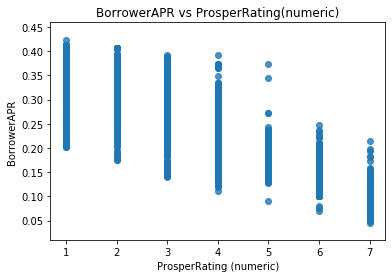

```python
#2.BorrowerAPR vs ProsperRating
sb.regplot(data=df_prosper_data1,x='ProsperRating (numeric)',y='BorrowerAPR',fit_reg=False)
plt.title("BorrowerAPR vs ProsperRating(numeric)")
```

#### There is a negative linear relationship between BorrowerAPR and ProsperRating.For high rating the borrowers pay less APR.

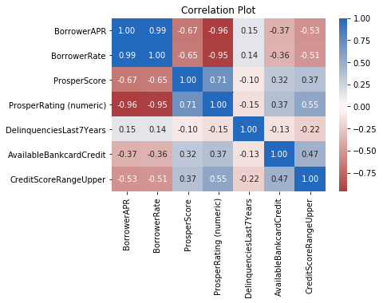

```python
#plot the correlation matrices for the below chosen numeric variables
num_var = ['BorrowerAPR', 'BorrowerRate','ProsperScore', 'ProsperRating (numeric)','DelinquenciesLast7Years',
             'AvailableBankcardCredit', 'CreditScoreRangeUpper']
sb.heatmap(df_prosper_data1[num_var].corr(),annot=True,fmt='.2f',cmap='vlag_r',center=0)
plt.title("Correlation Plot")
```

#### The above correlation matrix shows that borrowerAPR is high for negative prosperscore,i.e.Borrower has to pay high APR if their prosperscore is low. The borrowerAPR is also negative for high availablebankcredit and high creditscore.

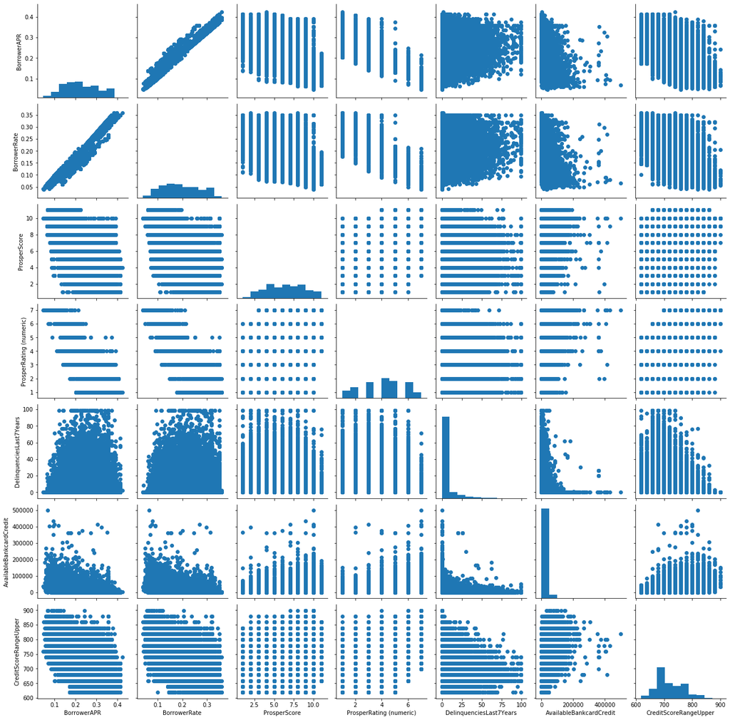

```python
#Plot the plot matrix of the below chosen numeric variables.
num_var = ['BorrowerAPR', 'BorrowerRate','ProsperScore', 'ProsperRating (numeric)','DelinquenciesLast7Years',
             'AvailableBankcardCredit', 'CreditScoreRangeUpper']
g=sb.PairGrid(data=df_prosper_data1,vars=num_var)
g.map_diag(plt.hist)
g.map_offdiag(plt.scatter)
```

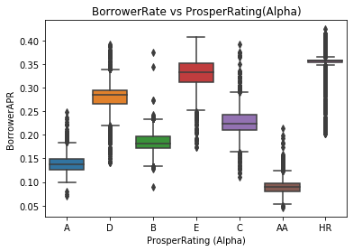

```python
#boxplot for BorrowerRate vs ProsperRating(Alpha)
sb.boxplot(data=df_prosper_data1,x='ProsperRating (Alpha)',y='BorrowerAPR')
plt.title("BorrowerRate vs ProsperRating(Alpha)")
```

```python
#statistical distribution for prosperrating(alpha)
df_prosper_data1.groupby(['ProsperRating (Alpha)'])['BorrowerAPR'].describe()
```

| ProsperRating (Alpha) | count | mean | std | min | 25% | 50% | 75% | max |
| --- | --- | --- | --- | --- | --- | --- | --- | --- |
| A | 14551.0 | 0.138909 | 0.016361 | 0.07045 | 0.12626 | 0.13799 | 0.14965 | 0.24807 |
| AA | 5372.0 | 0.090041 | 0.016905 | 0.04583 | 0.07922 | 0.09000 | 0.09736 | 0.21368 |
| B | 15581.0 | 0.184030 | 0.018343 | 0.08999 | 0.17151 | 0.18173 | 0.19645 | 0.37453 |
| C | 18345.0 | 0.226124 | 0.023306 | 0.11155 | 0.21025 | 0.22362 | 0.24246 | 0.39153 |
| D | 14274.0 | 0.280581 | 0.024580 | 0.14061 | 0.26528 | 0.28488 | 0.29510 | 0.39153 |
| E | 9795.0 | 0.330551 | 0.024768 | 0.17426 | 0.31159 | 0.33215 | 0.35132 | 0.40679 |
| HR | 6935.0 | 0.356061 | 0.019608 | 0.20260 | 0.35356 | 0.35797 | 0.35797 | 0.42395 |

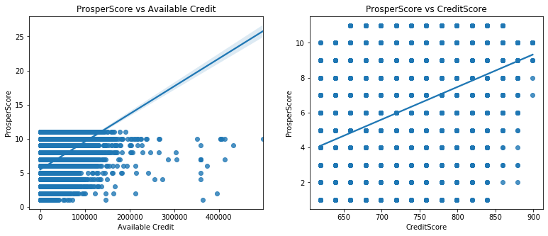

```python
#plot for prosperscore vs 'AvailableBankcardCredit', 'CreditScoreRangeUpper'
plt.figure(figsize=[13,5])

plt.subplot(1,2,1)
sb.regplot(data=df_prosper_data1,x='AvailableBankcardCredit',y='ProsperScore')
plt.xlabel("Available Credit")
plt.ylabel("ProsperScore")
plt.title("ProsperScore vs Available Credit")

plt.subplot(1,2,2)
sb.regplot(data=df_prosper_data1,x='CreditScoreRangeUpper',y='ProsperScore')
plt.xlabel("CreditScore")
plt.ylabel("ProsperScore")
plt.title("ProsperScore vs CreditScore")
```

#### ProsperScore is linearly replated to available credit and credit score

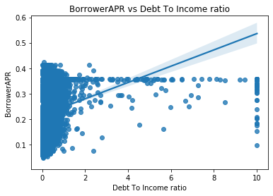

```python
#plot between BorrowerAPR and debt to income ratio

sb.regplot(data=df_prosper_data1,y='BorrowerAPR',x='DebtToIncomeRatio')
plt.xlabel("Debt To Income ratio")
plt.ylabel("BorrowerAPR")
plt.title("BorrowerAPR vs Debt To Income ratio")
```

### Did you observe any interesting relationships between the other features (not the main feature(s) of interest)?

> Available credit and creditscore is positively linear with Prosperscore while negatively linear with BorrowerAPR

## Multivariate Exploration

> Create plots of three or more variables to investigate your data even further. Make sure that your investigations are justified, and follow from your work in the previous sections.

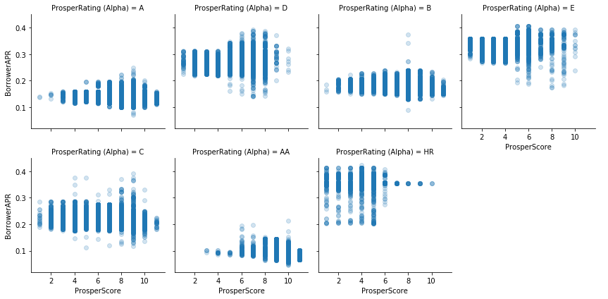

```python
# plot for borrowerAPR,ProsperScore,propser rating(alpha)
g=sb.FacetGrid(data=df_prosper_data1,col='ProsperRating (Alpha)',col_wrap = 4, size = 3)
g.map(plt.scatter,'ProsperScore','BorrowerAPR',alpha=.2)
g.add_legend()
```

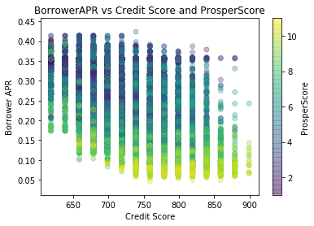

```python
# plot between borrowerAPR,ProsperScore,Creditscore

plt.scatter(data=df_prosper_data1,y='BorrowerAPR',x='CreditScoreRangeUpper',c='ProsperScore',alpha=.3)
plt.colorbar(label='ProsperScore')
plt.xlabel("Credit Score")
plt.ylabel("Borrower APR")
plt.title("BorrowerAPR vs Credit Score and ProsperScore")
```

#### Prosperscore and credit Score are positvely linear to each other while negatively linear to BorrowerAPR.Borrower with high credit score gets high prosperscore and so the low APR.

### Talk about some of the relationships you observed in this part of the investigation. Were there features that strengthened each other in terms of looking at your feature(s) of interest?

> The faceting grid has helped to see the different trends of the plots for the same set of variables.Also the correlation and plot matrix plots are very helpful to draw relationship between various features.